# The *Quickly* Word Prediction App

Carl Turner

April 20, 2016

## Background

Presenting mobile users with predictions of text can significantly improve the usability of entering text on small keyboards. This project attempts to balance speed and accuracy in a text prediction model by 1) using small samples of a large text database and 2) creating a fast algorithm for predicting next word text from user input. This approach sacrifices some accuracy for speed.

## Initial Line and Word Count

This first step simply opens the US English blog file, reads the file, and outputs it as an RDS file to be used in the Shiny app.

```r
library(ngram)
strTime <- Sys.time()
fileName <- "./data/final/en_US/en_US.blogs.txt"
con <- file(fileName,open="r")
txt <- readLines(con, skipNul = TRUE, n=3000)
close(con)

saveRDS(txt, "shiny/data/blogtxt.rds") #used in server.R
txt<-readRDS("shiny/data/blogtxt.rds") #used in server.R
endTime <- Sys.time()
timeRun <- difftime(endTime,strTime,units="auto")
timeRun
```

```
## Time difference of 0.4225521 secs
```

## Ngrams of Data Source

In this section the frequencies for individual words, 2-grams (bigrams), and 3-grams (trigrams), are caluculated for US blogs.

Pre-processing is done by removing non-alpha characters before computing word frequencies. Then the words are sorted by their frequency of occurance. The 10 most-frequent words are shown below.

```r
library(ngram)
library(stringr)
blogtxt = scan(text = txt, what="", quote=NULL, blank.lines.skip = TRUE)#######

blogtxt<-gsub("[^[:alnum:][:space:]\']", " ", blogtxt) #remove all punctuation except "'"
blogtxt<-gsub("â ", "\'", blogtxt)
blogtxt<-gsub("\\' ", "\\'", blogtxt)
blogtxt<-gsub(" [b-hj-z] "," ", blogtxt) #remove single letters except a,i
blogtxt<-preprocess(blogtxt)
blogtxt<-preprocess(blogtxt, case="lower", split.at.punct=FALSE)
blogcounts = as.data.frame(xtabs(~blogtxt))
blog.str = paste(blogtxt, collapse=" ")

library(tau)
blog.counts = textcnt(blog.str, n=1, method="string", tolower=T) #1-gram
blog.counts.df = data.frame(word = names(blog.counts), count = c(blog.counts))
head(blog.counts.df[order(blog.counts.df$count, decreasing = T),], 10)
```

```
##      word count
## the   the  6144
## and   and  3669
## to     to  3474
## i       i  3125
## a       a  2929
## of     of  2755
## in     in  1923
## that that  1616
## it     it  1589
## is     is  1369
```

```r
sum(blog.counts.df$count) #word count
```

```
## [1] 125005
```

### 2-grams

The 2-grams (bigrams) are created by taking each pair of words, then calculating the frequencies that each pair appears in the corpus. As shown in the figure, there are a small number of high-frequency 2-grams. The high-frequency 2-grams are shown in the table below the figure.

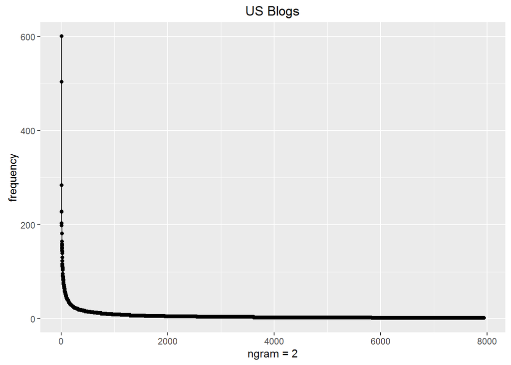

```r
library(ggplot2)
library(NLP)
library(tm)
blog.corpus = Corpus(VectorSource(blog.str))
blog.corpus = tm_map(blog.corpus, tolower)
cleaned.blog.str = as.character(blog.corpus)[1]
blog.words = strsplit(cleaned.blog.str, " ", fixed = T)[[1]]

blog.bigrams = vapply(ngrams(blog.words, 2), paste, "", collapse = " ")
blog.bigram.counts = as.data.frame(xtabs(~blog.bigrams))
blog.bigrams.y <- blog.bigram.counts[order(blog.bigram.counts$Freq, decreasing = T),]
y<-blog.bigrams.y
x<-c(1:length(y$Freq))

qplot(x, y$Freq,
      main = "US Blogs",
      xlab = "ngram = 2",
      ylab = "frequency",
      xlim = c(0, length(y$Freq)/10),
      na.rm = TRUE,
      geom = c("line", "point"))
```

```r
head(y)
```

```
##       blog.bigrams Freq
## 47925       of the  601
## 35060       in the  504
## 70980       to the  284
## 70092        to be  228
## 48656       on the  227
## 8308       and the  203
```

### 3-grams

The 3-grams (trigrams) are created from trios of words, then frequencies are calculated for each 3-gram. The distribution of 3-grams are shown in the figure and the names of the most frequent 3-grams are in the table below the figure.

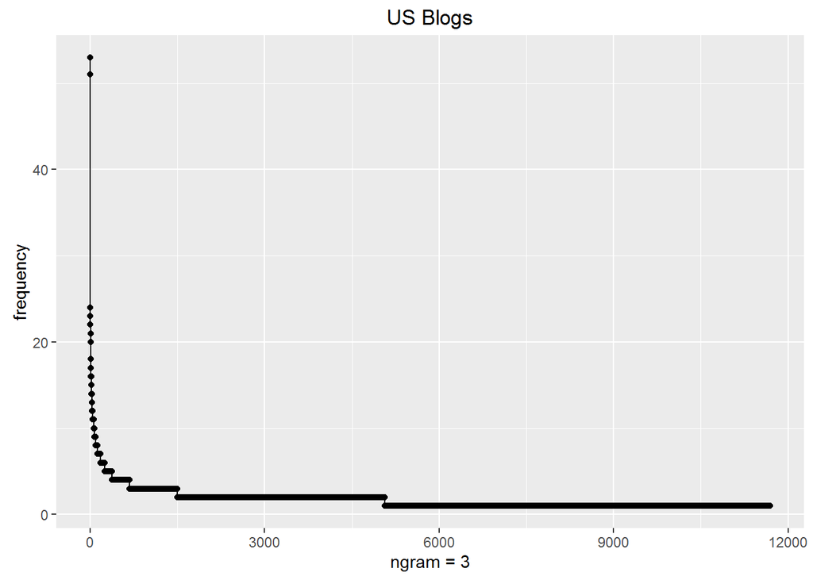

```r
library(ggplot2)
library(NLP)
library(tm)
blog.trigrams = vapply(ngrams(blog.words, 3), paste, "", collapse = " ")
blog.trigram.counts = as.data.frame(xtabs(~blog.trigrams))
blog.trigrams.y <- blog.trigram.counts[order(blog.trigram.counts$Freq, decreasing = T),]
y<-blog.trigrams.y
x<-c(1:length(y$Freq))

qplot(x, y$Freq,
      main = "US Blogs",
      xlab = "ngram = 3",
      ylab = "frequency",
      xlim = c(0, length(y$Freq)/10),
      na.rm = TRUE,
      geom = c("line", "point"))
```

```r
head(y)
```

```
##       blog.trigrams Freq
## 71423    one of the   53
## 4848       a lot of   51
## 54106      it was a   24
## 47194      i have a   23
## 93000    the end of   22
## 48080     i want to   21
```

## Prediction Function

### Matching Routine

```r
library(stringr)
trimInput <- function(userinp) {
    userinp<-str_replace_all(userinp, fixed("  "), " ")
    userinp<-str_trim(userinp)
    if (length(unlist(strsplit(userinp, " "))) < 3){
        userinp
    } else {
        userinpLen <- length(unlist(strsplit(userinp," ")))
        paste(word(userinp, userinpLen-1), word(userinp, userinpLen))
    }
}
getTrigram <- function(matches, userinp) {
    for(i in 1:length(matches$blog.trigrams)){
        if (word(matches$blog.trigrams[i],1) == word(userinp, 1)){
            #print(matches$blog.trigrams[i])
            return(word(matches$blog.trigrams[i], 3))
            break
        }
    }
}
getBigram <- function(matches, userinp) {
    for(i in 1:length(matches$blog.bigrams)){
        if (word(matches$blog.bigrams[i],1) == word(userinp, 2)){
            #print(matches$blog.bigrams[i])
            return(word(matches$blog.bigrams[i], 2))
            break
        }
    }
}
getPrediction <- function(userinp) {
    userinp <- trimInput(userinp)
    matches<-blog.trigrams.y[grep(userinp, blog.trigrams.y$blog.trigrams), ]
    if (dim(matches)[1]>0){
        getTrigram(matches, userinp)
    } else {
        matches<-blog.bigrams.y[grep(word(userinp, 2), blog.bigrams.y$blog.bigrams), ]
        if (dim(matches)[1]>0){
            getBigram(matches, userinp)
        } else {
            return("no prediction")
        }
    }
}
```

### Test Cases

```r
userinp <- c("one of") #a top trigram returns 'the'
#userinp <- c("one in") #not in trigram, but in bigram. "of" returns 'the'
#userinp <- c("one only") #not in trigram or bigram
getPrediction(userinp)
```

```
## [1] "the"
```